# Работа с данными о продажах

### Анализ продаж стандарт, про и преимум

Для того чтобы корректно все просчитать, требуется небольшой анализ покупок.

- Посмотрим как распределены покупки *ПРО* и *СТАНДРАРТ* по месяцам

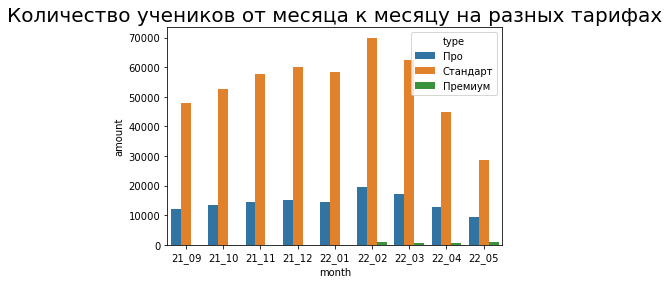

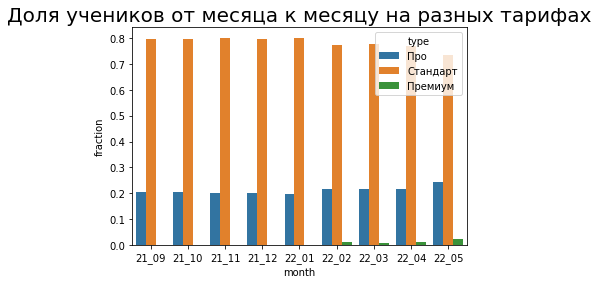

### Очень предварительные выводы

- Количество "Про" практически не меняется в первые месяцы (с 9 по 12), есть предположение, что это в большинстве своем те же самые люди

|  | index | month | unique_users | from 21_09 | from 21_10 | from 21_11 | from 21_12 | from 22_01 | from 22_02 | from 22_03 | from 22_04 | from 22_05 |
| --- | --- | --- | --- | --- | --- | --- | --- | --- | --- | --- | --- | --- |
| 0 | 0 | 21_10 | 9399 | 67.1 | NaN | NaN | NaN | NaN | NaN | NaN | NaN | NaN |
| 1 | 0 | 21_11 | 10211 | 57.7 | 74.2 | NaN | NaN | NaN | NaN | NaN | NaN | NaN |
| 2 | 0 | 21_12 | 10672 | 51.7 | 64.1 | 74.3 | NaN | NaN | NaN | NaN | NaN | NaN |
| 3 | 0 | 22_01 | 10197 | 46.2 | 55.6 | 62.4 | 71.4 | NaN | NaN | NaN | NaN | NaN |
| 4 | 0 | 22_02 | 14009 | 41.6 | 50.7 | 56.7 | 63.7 | 77.3 | NaN | NaN | NaN | NaN |
| 5 | 0 | 22_03 | 12357 | 36.9 | 43.8 | 49.1 | 55.3 | 67.5 | 74.1 | NaN | NaN | NaN |
| 6 | 0 | 22_04 | 9053 | 29.0 | 34.1 | 37.3 | 42.5 | 51.7 | 55.0 | 66.3 | NaN | NaN |
| 7 | 0 | 22_05 | 6863 | 21.9 | 25.2 | 27.1 | 31.0 | 36.7 | 39.4 | 46.9 | 65.2 | NaN |

- Скажем 64.1% учеников декабря (столбец month = 21_12) учились в октябре (столбец "from 21_10")
- Таблица показывает, что в среднем от месяца к месяцу "Про" продлевает больше половины учеников, но менее 80% учеников
- Предположение о том, что "Про" берут одни и те же ученики (из-за того, что их количество значительно не меняется) не подтвердилось
- Однако здесь можно видеть потенциальную зону роста
- Надо иметь ввиду, что здесь рассматривались только ученики, без привязки к предмету, то есть 1 ученик и много продуктов - это один ученик

### Анализ количества продкутов взятых учениками в отдельный месяц

- Для начала попробуем понять, много ли нас учеников, которые взяли И про И стандарт в одном месяце

|  | month | number |
| --- | --- | --- |
| 0 | 21_09 | 1289 |
| 0 | 21_10 | 1352 |
| 0 | 21_11 | 1444 |
| 0 | 21_12 | 1643 |
| 0 | 22_01 | 1531 |
| 0 | 22_02 | 2228 |
| 0 | 22_03 | 1821 |
| 0 | 22_04 | 1226 |
| 0 | 22_05 | 812 |

Мы пришли к тому, что у нас довольно много учеников ПРО которые почему-то покупают ещё и СТАНДАРТ. Это усложняет задачу их разделения на разные группы

- Разберёмся с тем, сколько учеников переходят из ПРО в СТАНДАРТ

| month_y month_x | 21_09 | 21_10 | 21_11 | 21_12 | 22_01 | 22_02 | 22_03 | 22_04 | 22_05 |
| --- | --- | --- | --- | --- | --- | --- | --- | --- | --- |
| 21_09 | NaN | 1554.0 | 1785.0 | 1762.0 | 1736.0 | 1661.0 | 1495.0 | 1075.0 | 803.0 |
| 21_10 | 818.0 | NaN | 1377.0 | 1547.0 | 1652.0 | 1653.0 | 1496.0 | 1093.0 | 848.0 |
| 21_11 | 840.0 | 519.0 | NaN | 1168.0 | 1461.0 | 1614.0 | 1509.0 | 1104.0 | 886.0 |
| 21_12 | 868.0 | 592.0 | 454.0 | NaN | 1236.0 | 1476.0 | 1438.0 | 1077.0 | 923.0 |
| 22_01 | 822.0 | 590.0 | 516.0 | 410.0 | NaN | 981.0 | 1140.0 | 925.0 | 868.0 |
| 22_02 | 1389.0 | 1228.0 | 1253.0 | 1181.0 | 1233.0 | NaN | 1495.0 | 1304.0 | 1227.0 |
| 22_03 | 1216.0 | 1068.0 | 1125.0 | 1038.0 | 1094.0 | 538.0 | NaN | 826.0 | 1055.0 |
| 22_04 | 914.0 | 788.0 | 842.0 | 789.0 | 831.0 | 508.0 | 371.0 | NaN | 827.0 |
| 22_05 | 790.0 | 716.0 | 804.0 | 800.0 | 846.0 | 705.0 | 636.0 | 532.0 | NaN |

- Данная таблица демонстрирует количество переходов из ПРО в СТАНДАРТ для пары месяцев. month_x - из которого, month_y - в который.
- Надо понимать, что если month_y идёт раньше, то эта пара обозначает обратный процесс - те кто учился в СТАНДАРТ в month_y вдруг стали учиться в ПРО в month_x

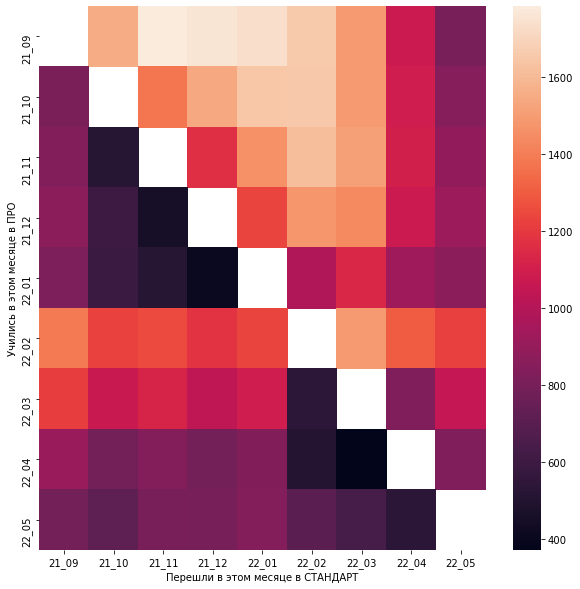

- График выше работает в обе стороны. Верхний треугольник - это уходы из ПРО в СТАНДАРТ, а нижний треугольник - Переходы из СТАНДАРТ в ПРО

### Расчёт и оптимизация

- Ниже я запищу формулы и функции, которые предстоит оптимизировать

### Переменные СТАНДАРТ

$N$ - количество учеников, которые купили СТАНДАРТ $$N = N_1 + N_2 + N_3 + N_4$$, где $N_1, N_2, N_3, N_4$ - это количество учеников, которые купили соответственно $1,2,3,4$ предмета $P_a$ - количество купленных продуктов СТАНДАРТ $$P_a = N_1 + 2\cdot N_2 + 3\cdot N_3 + 4\cdot N_4$$

$a_i$ - стоимость продукта СТАНДАРТ при покупке i пакетов. То есть $a_3$ - стоимость одного пакета, при покупке трех сразу

$S_a$ - общий доход от продажи пакетов СТАНДАРТ

$$S_a = (N_1+N_2+N_3+N_4)\cdot a_1 + (N_2+N_3+N_4)\cdot a_2+ (N_3+N_4)\cdot a_3+ N_4\cdot a_4 $$

### Переменные ПРО

$M$ - количество учеников, которые купили ПРО $$M = M_1 + M_2 + M_3 + M_4$$, где $M_1, M_2, M_3, M_4$ - это количество учеников, которые купили соответственно $1,2,3,4$ предмета $P_b$ - количество купленных продуктов ПРО $$P_b = M_1 + 2\cdot M_2 + 3\cdot M_3 + 4\cdot M_4$$

$b_i$ - стоимость продукта ПРО при покупке i пакетов. То есть $b_3$ - стоимость одного пакета, при покупке трех сразу

$S_b$ - общий доход от продажи пакетов СТАНДАРТ

$$S_b = (M_1+M_2+M_3+M_4)\cdot b_1 + (M_2+M_3+M_4) \cdot b_2+ (M_3+M_4)\cdot b_3+ M_4\cdot b_4 $$

### Ограничения

- Сумма $ S_a + S_b $должна быть не менее чем 186 000 000 $$S = S_a + S_b > 186 \cdot 10^6$$
- Количество продуктов ПРО и СТАНДАРТ должны относиться друг к другу не менее чем 3 к 7 (если больше - даже лучше) $$\frac{P_a}{P_b}>\frac{3}{7}$$
- Соотношение количества покупок 1,2,3,4 пакетов СТАНДАРТ и ПРО должно соответствовать прошлогоднему соотношению: $$N_1:N_2:N_3:N_4 \approx \alpha_1 : \alpha_2 : \alpha_3 : \alpha_4$$ $$M_1:M_2:M_3:M_4 \approx \beta_1 : \beta_2 : \beta_3 : \beta_4$$
- Общее количество пакетов на одного человека должно стать быть не мнее 1.69: $$\frac{P_a+P_b}{N+M} > 1.69$$

### Попытаемся определить соотношения $\alpha_1, \alpha_2, \alpha_3, \alpha_4$ и $\beta_1, \beta_2, \beta_3, \beta_4$

- Сначала разбираемся со СТАНДАРТ

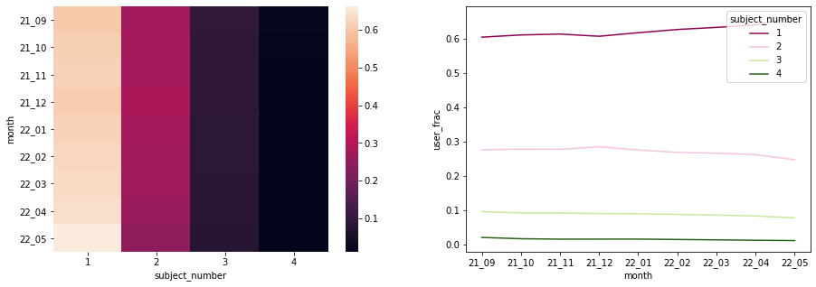

- На картинки выше хорошо видно, что от месяца к месяцу доля учеников покупавших 1-2-3-4 предмета практически не меняется
- Взяв среднее по всем месяцам получили $\alpha_1 = 63\%$, $\alpha_2 = 27\%$, $\alpha_3 = 9\%$, $\alpha_4 = 1\%$
- Далее делаем то же самое с ПРО

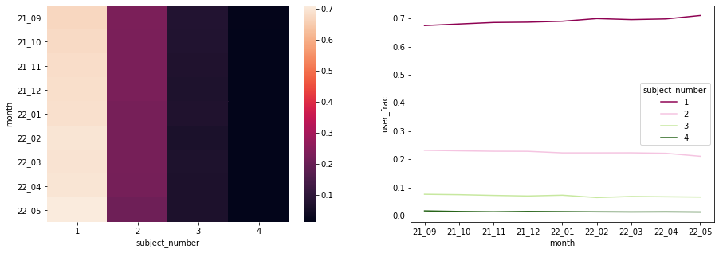

- Дела с ПРО обстоят, на удивление, примерно так же как и с СТАНДАРТ
- Полученные коэффициенты $\beta_1 = 69\%$, $\beta_2 = 22\%$, $\beta_3 = 7\%$, $\beta_4 = 1\%$

### Используя полученные коэффициенты мы будем строить модель, которая подберёт нужное количество $N_1,N_2,N_3,N_4$ и $M_1,M_2,M_3,M_4$

- Будем брать цены сразу со скидкой

|  | index | N_1 | N_2 | N_3 | N_4 | M_1 | M_2 | M_3 | M_4 | N | M | all_users | st_poducts | pro_products | all_products | sum | products_per_user |
| --- | --- | --- | --- | --- | --- | --- | --- | --- | --- | --- | --- | --- | --- | --- | --- | --- | --- |
| 0 | 0 | 15877 | 6464 | 2046 | 215 | 7452 | 2257 | 682 | 92 | 24602 | 10483 | 35085 | 35803 | 14380 | 50183 | 186002050 | 1.430326 |
| 1 | 0 | 15878 | 6464 | 2046 | 215 | 7453 | 2257 | 682 | 92 | 24603 | 10484 | 35087 | 35804 | 14381 | 50185 | 186010230 | 1.430302 |
| 2 | 0 | 15879 | 6465 | 2047 | 216 | 7453 | 2257 | 682 | 92 | 24607 | 10484 | 35091 | 35814 | 14381 | 50195 | 186042925 | 1.430424 |
| 3 | 0 | 15880 | 6465 | 2047 | 216 | 7453 | 2257 | 682 | 92 | 24608 | 10484 | 35092 | 35815 | 14381 | 50196 | 186046615 | 1.430411 |
| 4 | 0 | 15881 | 6465 | 2047 | 216 | 7454 | 2257 | 682 | 92 | 24609 | 10485 | 35094 | 35816 | 14382 | 50198 | 186054795 | 1.430387 |
| ... | ... | ... | ... | ... | ... | ... | ... | ... | ... | ... | ... | ... | ... | ... | ... | ... | ... |
| 29548 | 0 | 43947 | 17892 | 5665 | 597 | 20628 | 6248 | 1888 | 256 | 68101 | 29020 | 97121 | 99114 | 39812 | 138926 | 514921340 | 1.430442 |
| 29549 | 0 | 43948 | 17893 | 5666 | 598 | 20629 | 6248 | 1888 | 256 | 68105 | 29021 | 97126 | 99124 | 39813 | 138937 | 514958525 | 1.430482 |
| 29550 | 0 | 43949 | 17893 | 5666 | 598 | 20629 | 6248 | 1888 | 256 | 68106 | 29021 | 97127 | 99125 | 39813 | 138938 | 514962215 | 1.430478 |
| 29551 | 0 | 43950 | 17893 | 5666 | 598 | 20629 | 6248 | 1888 | 256 | 68107 | 29021 | 97128 | 99126 | 39813 | 138939 | 514965905 | 1.430473 |
| 29552 | 0 | 43951 | 17894 | 5666 | 598 | 20630 | 6248 | 1888 | 256 | 68109 | 29022 | 97131 | 99129 | 39814 | 138943 | 514980800 | 1.43047 |

29553 rows × 17 columns

# Объяснение и Итоги

### Объяснения

Генерация данных происходила так:

```
- Мы берём минимальное количество учеников за прошлый год, купивших СТАНДАРТ и идём в сторону увеличения
- Отталкиваясь от этого числа, мы высчитываем все остальные числа: количество тех кто купил 1-2-3-4 мастерку СТАНДАРТ
- Из пропорции 3/7 мы получаем количество покупок мастерки ПРО
- Проверяем условия пропорций, суммы и прочего - записываем все просчитанные варианты в таблицу
- Самое первое учисло увеличиваем пока не доберёмся до максимального количества учеников за прошлый год, умноженного на 1.1 (то есть увеличенный на 10% лучший результат прошлого года)
```

### Итоги

- Последняя таблица предлагает 29.5 тысяч вариантов как можно достигнуть искомых целей
- Не все варианты реализуемы, однако самые первые - вполне
- Для примера: 24602 учеников СТАНДАРТ и 10483 учеников ПРО приносят 186002050 рублей, купив 50183 продуктов
- Проблема с количеством продуктов на одного ученика. Это число почти никак не меняется и равняется 1.43
- В реальности это число будет больше, примерно на 5-10%, то есть 1.5-1.57, но врятли больше
- Скорее всего число 1.43 можно математически получить из коэффициентов $\alpha_1,\alpha_2,\alpha_3,\alpha_4$ и $\beta_1,\beta_2,\beta_3,\beta_4$. Доказательством этого я займусь позже

## P.S.

### Математическое доказательство того, что при заданных $\alpha_1,\alpha_2,\alpha_3,\alpha_4$ и $\beta_1,\beta_2,\beta_3,\beta_4$ число продуктов на человека - ограничено

Число продуктов на человека(Products per user) будет задано следующим образом: $$P_{pu} = \frac{N_1 + 2\cdot N_2 + 3\cdot N_3 + 4\cdot N_4 + M_1 + 2\cdot M_2 + 3\cdot M_3 + 4\cdot M_4}{N_1+N_2+N_3+N_4+M_1+M_2+M_3+M_4}$$
Так как общее количество учеников СТАНДАРТ и ПРО связано с $N_i$ и $M_i$ через коэффициенты $\alpha_i$ и $\beta_i$, то мы можем выразить явно: $$P_{pu} = \frac{N\cdot(\alpha_1 + 2\cdot \alpha_2 + 3\cdot \alpha_3 + 4\cdot \alpha_4) + M\cdot(\beta_1 + 2\cdot\beta_2+3\cdot\beta_3+4\cdot\beta_4)}{N+M}$$
Обозначим:

- $\alpha_1 + 2\cdot \alpha_2 + 3\cdot \alpha_3 + 4\cdot \alpha_4 = A$
- $\beta_1 + 2\cdot\beta_2+3\cdot\beta_3+4\cdot\beta_4 = B$

Помимо того мы знаем, что N и M связаны соотношением $C = 3/7$. В итоге получаем: $$P_{pu} = \frac{N\cdot A + C\cdot N\cdot B}{N + C\cdot N} = \frac{A+C\cdot B}{1+C}$$

- Выше хорошо показано, что в течении года $\alpha_i$ и $\beta_i$ практически не меняются, и скорее всего глобально не подвергаются изменению, а значит $A$ и $B$ зафиксированы
- Коэффициент $C = 3/7$ продитован бизнес задачами, и выражает соотношение между ПРО и СТАНДАРТ.
- Все перечисленное выше доказывает, что $P_{pu}$ ограничено при заданных условиях. В нашем случае оно равно 1.43